# Monte Carlo simulations

# Birthday problem

Conduct a Monte Carlo simulation to answer the following questions related to the birthday problem or birthday paradox.

1. What is the probability of at least two people sharing the same birthday (month and day) from a random sample of 23 individuals?
2. What is the probability of at least two people sharing the same birthday (month and day) from a random sample of 70 individuals?
3. Create a plot using `ggplot` with the number of individuals on the x-axis and the probability of at least one pair on the y-axis. You should simulate the probability of at least two people sharing the same birthday for each number of individuals from 2 to 100.

You may ignore leap year and assume 365 days per year. The number of simulation replications you choose is at your discretion, but if you choose a number too small the results will not be accurate.

```r
#create a fuction bday.match(n) which will check whether there is a birthday match in a year between `n` individuals
bday.match <- function(n){ 1 - (prod(seq(365,by=-1,length=n))/365^n)
}
# For (a) check probability of match for 23 people
emp.23 <- mean(replicate(100000, bday.match(23)))
emp.23
```

```
[1] 0.5072972
```

```r
#(b)
emp.70 <- mean(replicate(100000, bday.match(70)))
emp.70
```

```
[1] 0.9991596
```

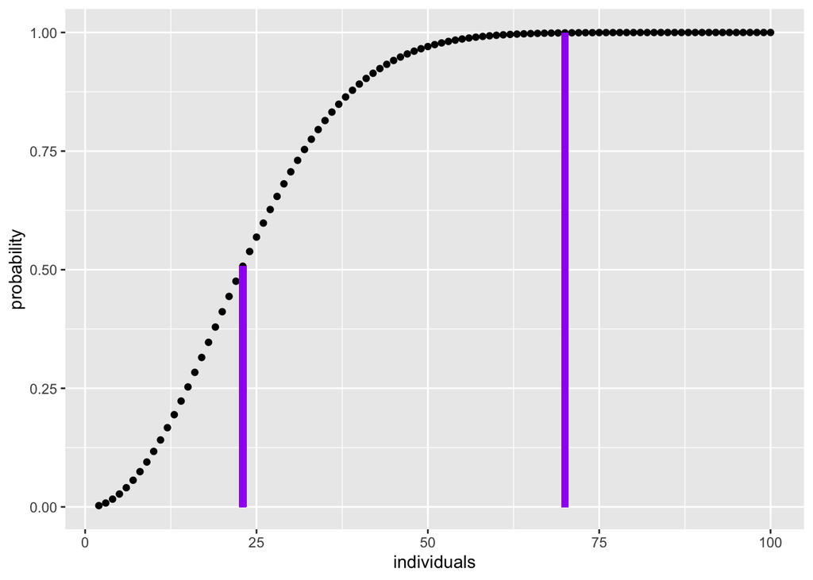

```r
# Here're the steps to create the dataframe needed for part (c)
nmat <- matrix(c(2:100))
event.results <- replicate(10000, apply(nmat, 1, bday.match))
emp.results <- apply(event.results, 1, mean)
emp.results.df <- data.frame(n = nmat, emp.prob = emp.results)

ggplot(emp.results.df, aes(n, emp.prob)) +
  geom_point() +
  labs(x="individuals", y = "probability") +
  geom_segment(color= "purple", size =2, x=23, xend=23, y=0, yend=emp.23)+
  geom_segment(color= "purple", size =2, x=70, xend=70, y=0, yend=emp.70)
```

# References

https://ggplot2.tidyverse.org/reference/geom_segment.html

1. http://news.mit.edu/2010/exp-monte-carlo-0517
2. https://en.wikipedia.org/wiki/Antoine_Gombaud